# Assignment 15

#### **Part d**: Graduation rate seems to be consistently around 0.9 except for 4 extremely low values, 1 of which is at around 37% people of color and the others concentrated around 75% to 100% people of color.

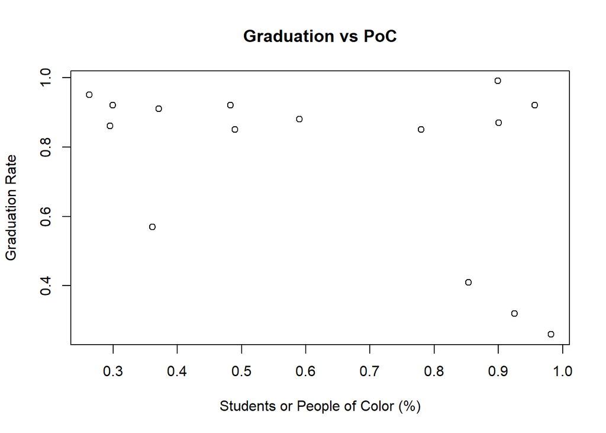

```r
plot(data$Percent_POC, data$Grad_Rate, xlab="Students or People of Color (%)", ylab="Graduation Rate", main = "Graduation vs PoC")
```

#### **Part e**: $H_0: \mu_0=\mu_1=\mu_2$, $H_A:$ at least one of the means is different

#### **Part f**: P-value is 0.0207 which is less than alpha of 0.05. We would reject the null hypothesis meaning that at least one of the graduation means is different between the redlined districts.

```r
summary(aov(Grad_Rate ~ Letter, data=data))
```

```
##             Df Sum Sq Mean Sq F value Pr(>F)
## Letter       3 0.4835 0.16118   4.935 0.0207 *
## Residuals   11 0.3592 0.03266
## ---
## Signif. codes:  0 '***' 0.001 '**' 0.01 '*' 0.05 '.' 0.1 ' ' 1
```

#### **Part g**: The p-value was pretty surprising as it was a lot higher than I expected looking at the boxplots. The median and boxes for the plots varied quite a bit and seemed quite different so a p-value of 0.02 was really high. This could be due to the difference in variance of the different categories where we have group D with really high variance and group B with really low. C and None groups are in between but also lean towards lower variance so it’s quite all over the place.

```r
for (a in unique(data$Letter)){
  print(a)
  print(var(data$Grad_Rate[data$Letter == a], na.rm=T))
}
```

```
## [1] "B"
## [1] 0.00083
## [1] "C"
## [1] 0.00405
## [1] "D"
## [1] 0.08725
## [1] "None"
## [1] 0.001433333
```

```r
summary(aov(Grad_Rate ~ Letter, data=data))
```

```
##             Df Sum Sq Mean Sq F value Pr(>F)
## Letter       3 0.4835 0.16118   4.935 0.0207 *
## Residuals   11 0.3592 0.03266
## ---
## Signif. codes:  0 '***' 0.001 '**' 0.01 '*' 0.05 '.' 0.1 ' ' 1
```

```r
diff <- mean(data$Grad_Rate[data$Letter=="B"], na.rm=T) - mean(data$Grad_Rate[data$Letter=="C"])
sp2 <- 0.03266
se <- sqrt(sp2/length(data$Grad_Rate[data$Letter=="B"]) + sp2/length(data$Grad_Rate[data$Letter=="C"]))
se
```

```
## [1] 0.1512019
```

```r
ts <- diff/se
ts
```

```
## [1] 3.630908
```

```r
2*pt(ts, 11, lower.tail=F)
```

```
## [1] 0.003950371
```

```r
0.05/6
```

```
## [1] 0.008333333
```

# **Wizard**

## Problem 3

#### **Part a**:

```r
## Simulate random data for 5 different groups, each from a Normal distribution
##  with slightly different means and standard deviations.
##  Using `round` to keep the numbers manageable
A <- round(rnorm(20, 1, 2.5),2)
B <- round(rnorm(20, 1.5, 2.5),2)
C <- round(rnorm(20, 1.75, 2.5),2)
D <- round(rnorm(20, 2, 2.5),2)
E <- round(rnorm(20, 2.5, 2.5),2)
## Combine all of this data
data <- c(A, B, C, D, E)
## Create the group designations
groups <- c(rep("A", 20), rep("B", 20), rep("C", 20), rep("D", 20), rep("E", 20))
## Put everything into a data.frame and label the columns
my.dat <- data.frame(data, groups)
colnames(my.dat) <- c("data", "groups")
```

#### **Part b**: Medians are pretty consistent and middle 50% are around the same level as well. There is quite a bit of variation in the size of middle 50% so that might be a problem.

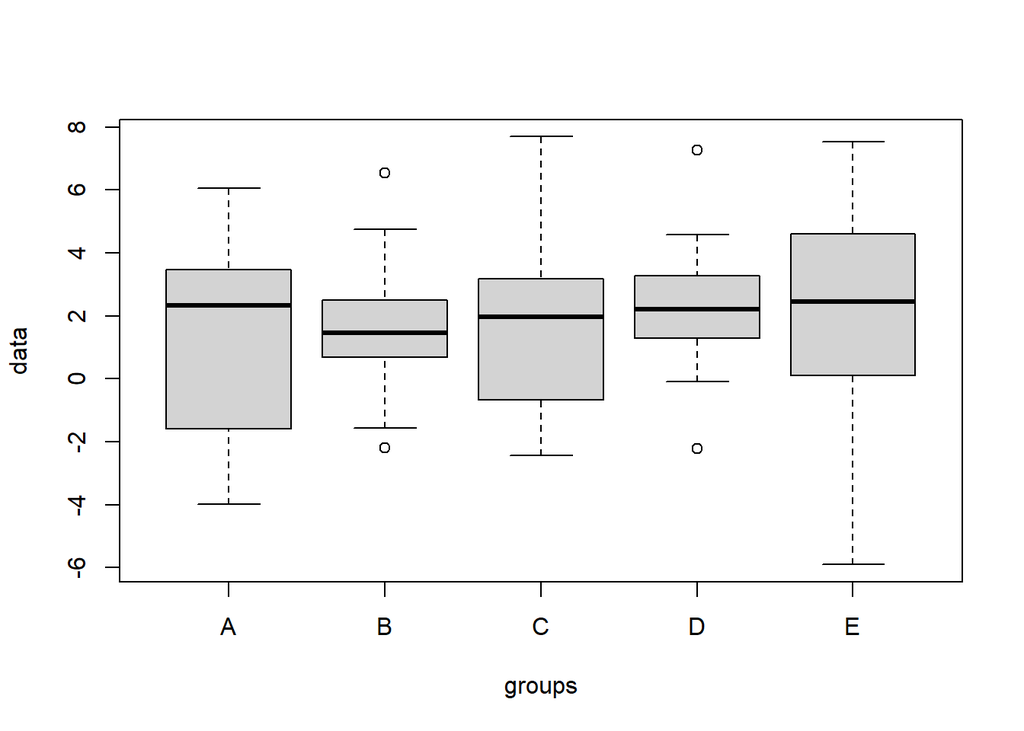

```r
boxplot(data ~ groups, data=my.dat)
```

```r
summary(aov(data ~ groups, data=my.dat))
```

```
##             Df Sum Sq Mean Sq F value Pr(>F)
## groups       4    8.1   2.022   0.292  0.883
## Residuals   95  658.2   6.928
```

#### **Part d**: We see a more upwards tilt across the groups instead of them being approximately flat. The variation still differs a bit across the categories as well.

```r
A <- round(rnorm(20, 1 - 0.125, 2.5),2)
B <- round(rnorm(20, 1.5 - 0.1, 2.5),2)
C <- round(rnorm(20, 1.75, 2.5),2)
D <- round(rnorm(20, 2 + 0.1, 2.5),2)
E <- round(rnorm(20, 2.5 + 0.125, 2.5),2)
data <- c(A, B, C, D, E)
groups <- c(rep("A", 20), rep("B", 20), rep("C", 20), rep("D", 20), rep("E", 20))
my.dat <- data.frame(data, groups)
colnames(my.dat) <- c("data", "groups")
summary(aov(data ~ groups, data=my.dat))
```

```
##             Df Sum Sq Mean Sq F value Pr(>F)
## groups       4   64.5   16.14   3.022 0.0215 *
## Residuals   95  507.3    5.34
## ---
## Signif. codes:  0 '***' 0.001 '**' 0.01 '*' 0.05 '.' 0.1 ' ' 1
```

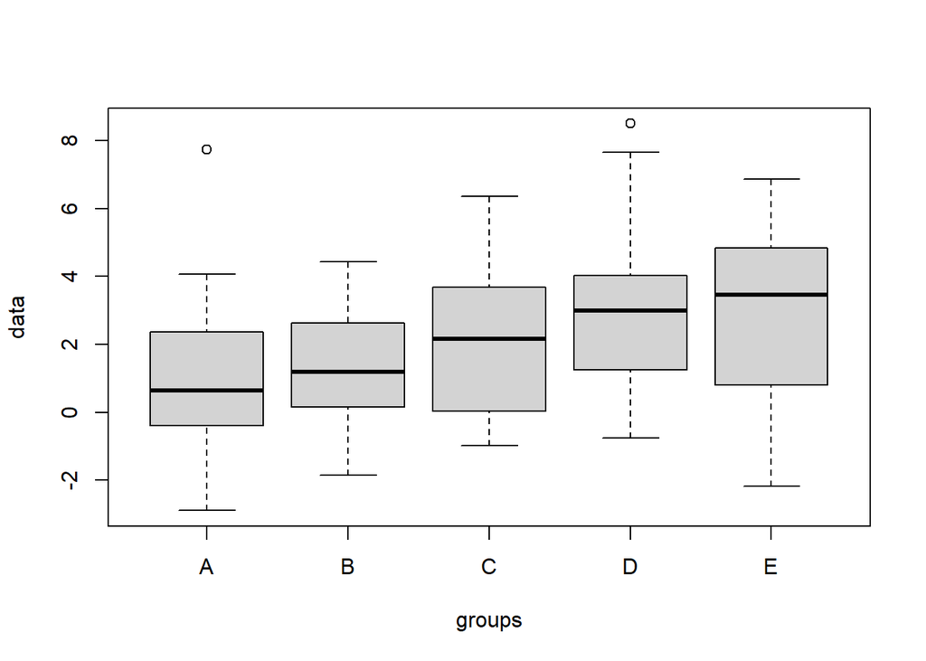

```r
boxplot(data ~ groups, data=my.dat)
```

```r
A <- round(rnorm(20, 1 - 0.125, 5),2)
B <- round(rnorm(20, 1.5 - 0.1, 5),2)
C <- round(rnorm(20, 1.75, 5),2)
D <- round(rnorm(20, 2 + 0.1, 5),2)
E <- round(rnorm(20, 2.5 + 0.125, 5),2)
data <- c(A, B, C, D, E)
groups <- c(rep("A", 20), rep("B", 20), rep("C", 20), rep("D", 20), rep("E", 20))
my.dat <- data.frame(data, groups)
colnames(my.dat) <- c("data", "groups")
summary(aov(data ~ groups, data=my.dat))
```

```
##             Df Sum Sq Mean Sq F value Pr(>F)
## groups       4     85   21.24   0.926  0.452
## Residuals   95   2179   22.94
```

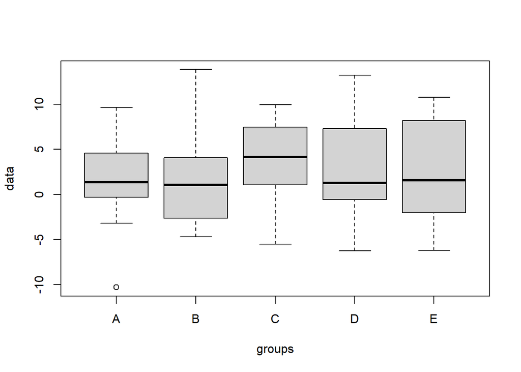

```r
boxplot(data ~ groups, data=my.dat)
```

```r
A <- round(rnorm(20, 1 - 0.125, 2.5),2)
B <- round(rnorm(20, 1.5 - 0.1, 2.5),2)
C <- round(rnorm(20, 1.75, 2.5),2)
D <- round(rnorm(20, 2 + 0.1, 2.5),2)
E <- round(rnorm(20, 2.5 + 0.125, 10),2)
data <- c(A, B, C, D, E)
groups <- c(rep("A", 20), rep("B", 20), rep("C", 20), rep("D", 20), rep("E", 20))
my.dat <- data.frame(data, groups)
colnames(my.dat) <- c("data", "groups")
summary(aov(data ~ groups, data=my.dat))
```

```
##             Df Sum Sq Mean Sq F value Pr(>F)
## groups       4     88   22.03   0.602  0.662
## Residuals   95   3475   36.58
```

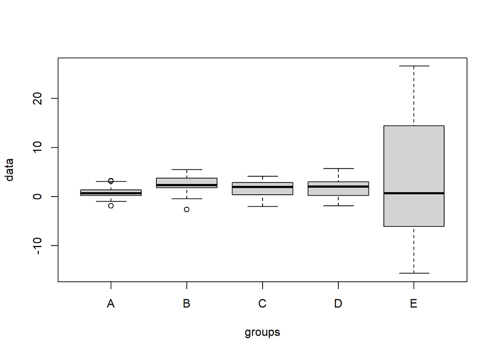

```r
boxplot(data ~ groups, data=my.dat)
```